# UGR Multivariante Discriminante

franmarq@gmail.com

2022-12-04

En primer lugar hacemos la lectura de los datos y resumimos los mismos para validar la correcta lectura.

```r
datos<-read.table("discriminante2.txt", header=TRUE)
attach(datos)
str(datos)
```

```
## 'data.frame':    34 obs. of  4 variables:
##  $ ansiedad: int  1 1 1 1 1 1 1 1 1 1 ...
##  $ X1      : num  6.5 6.2 5.8 6.5 6.5 6.9 7.2 6.9 6.1 6.3 ...
##  $ X2      : num  9.5 9.9 9.6 9.6 9.2 9.1 10 9.9 9.5 9.4 ...
##  $ X3      : num  4.4 6.4 3 4.1 0.8 5.7 2 3.9 1.9 5.7 ...
```

Ahora, hacemos inicialmente la comprobacion de las Hipotesis sobre los datos, que validarian la aplicacion de la tecnica:

Hipotesis: Normalidad

```r
library(mvnormtest)
shapiro.test(t(datos[,2:4]))
```

```
##
##  Shapiro-Wilk normality test
##
## data:  t(datos[, 2:4])
## W = 0.92656, p-value = 2.682e-05
```

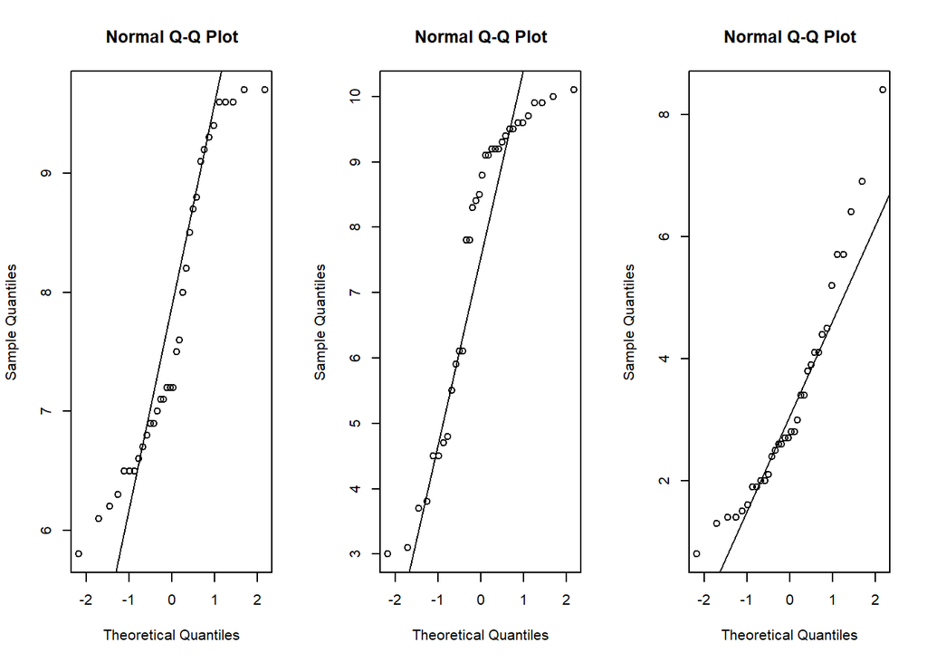

```r
par(mfrow = c(1,3))
qqnorm(datos$X1)
qqline(datos$X1)

qqnorm(datos$X2)
qqline(datos$X2)

qqnorm(datos$X3)
qqline(datos$X3)
```

```r
par(mfrow = c(1,1))
```

A partir del resultado del Test Shapiro, p=2.682e-05, se rechaza la hipotesis nula, lo que sugiere que las variables X1,X2,X3 no presentan un comportamiento normal.

Hipotesis: Igualdad de varianzas-covarianzas

```r
homocedasticidad_tratamiento=bartlett.test(list(datos$X1, datos$X2, datos$X3))
print(homocedasticidad_tratamiento)
```

```
##
##  Bartlett test of homogeneity of variances
##
## data:  list(datos$X1, datos$X2, datos$X3)
## Bartlett's K-squared = 11.978, df = 2, p-value = 0.002506
```

El resultado del test de Barlett sugiere el rechazo de la hipotesis nula, en otras palabras, indica que las variables no representan igualdad de varianzas.

Hipotesis: No multicolinealidad

```r
cor(datos[c("X1","X2","X3")], use="complete")
```

```
##            X1         X2         X3
## X1  1.0000000 -0.7300793 -0.4236522
## X2 -0.7300793  1.0000000  0.3670388
## X3 -0.4236522  0.3670388  1.0000000
```

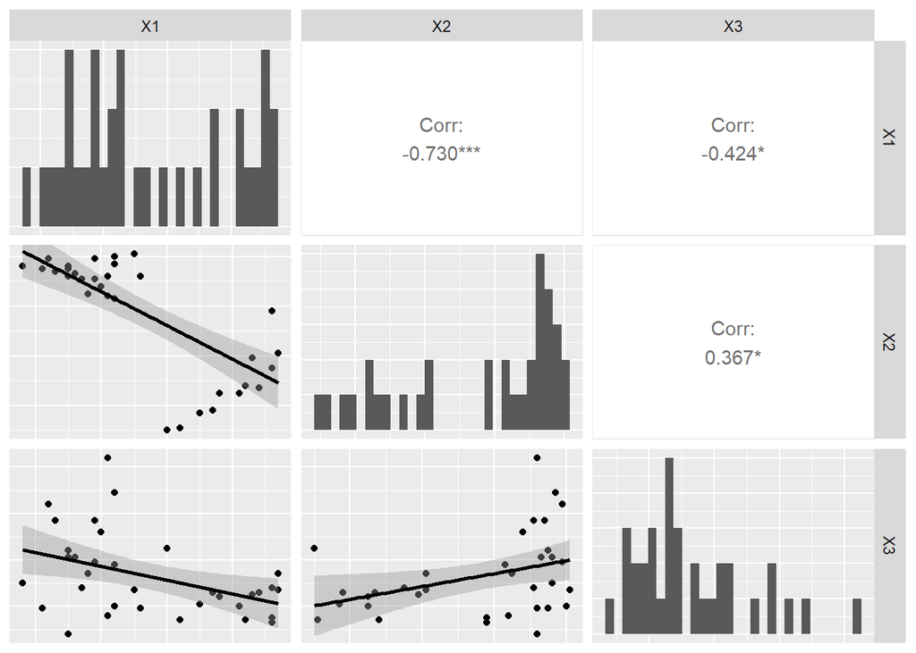

```r
ggpairs(datos[,2:4], lower = list(continuous = "smooth"),
diag = list(continuous = "barDiag"), axisLabels = "none")
```

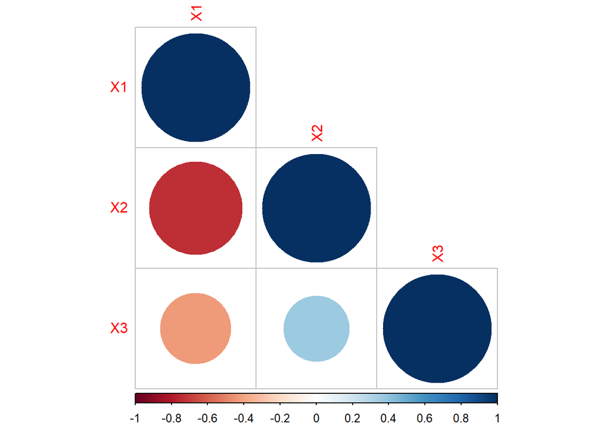

```r
corrplot(cor(datos[c("X1","X2","X3")], use="complete"),sig.level=0.05,typ="lower")
```

Dados los resultados tanto de la matriz de covarianzas asi como el grafico, vemos que efectivamente entre las variables X1 y X2 podemos tener un problema de colinealidad por valores que indican alto grado de relacion bivariante.Para el resto de combinaciones no se presenta este comportamiento.

Ahora iniciamos el analisis Discriminante:

Consideramos que las probabilidades de pertenencia a cada grupo son iguales. Usaremos, ademas, el metodo de los momentos para la estimacion

```r
discrimi<-lda(ansiedad~X1+X2+X3,prior=c(0.33,0.33,0.34), method="moment", tol=0.001)
discrimi
```

```
## Call:
## lda(ansiedad ~ X1 + X2 + X3, prior = c(0.33, 0.33, 0.34), method = "moment",
##     tol = 0.001)
##
## Prior probabilities of groups:
##    1    2    3
## 0.33 0.33 0.34
##
## Group means:
##     X1       X2       X3
## 1 6.49 9.570000 3.790000
## 2 7.08 9.060000 4.080000
## 3 9.10 5.092857 2.371429
##
## Coefficients of linear discriminants:
##             LD1        LD2
## X1  2.763113352 -0.8926737
## X2 -1.180044092 -0.3316161
## X3 -0.009738474 -0.4716923
##
## Proportion of trace:
##    LD1    LD2
## 0.9986 0.0014
```

Del resultado obtenemos lo siguiente:

La tabla con las probabilidades a priori de pertenencia a cada grupo. Los centroides de los grupos. Los coeficientes de las funciones discriminantes. En nuestro caso dos en funcion de las 3 variables.

Resultando las siguientes funciones:

D1= +2.763X1-1.180X2-0.009X3 D2= -0.892X1-0.331X2-0.471X3

Ahora, obtenemos la proporcion de varianza explicada por cada eje

```r
discrimi$svd
```

```
## [1] 22.5655057  0.8395045
```

Ahora realizamos la prediccion sobre el individuo.

```r
Datos2<-rbind(c(7.5, 9, 2))
Datos21<-data.frame(Datos2)
discrimi2<-predict(discrimi,newdata=Datos21,prior=discrimi$prior,2)
discrimi2
```

```
## $class
## [1] 2
## Levels: 1 2 3
##
## $posterior
##             1         2            3
## 1 0.006135785 0.9938642 5.206912e-18
##
## $x
##         LD1       LD2
## 1 -1.507827 0.3547427
```

El resultado nos indica que el individuo tiene probabilidad de 0.993 de pertenecer al grupo 2, lo que confirmaria su pertenencia al grupo N2 de acuerdo a su ansiedad de fumar.

Obtenemos ahora la matrix de confusion

```r
table(predict(discrimi)$class, ansiedad)
```

```
##    ansiedad
##      1  2  3
##   1  8  2  0
##   2  2  8  0
##   3  0  0 14
```

```r
#ansiedad
```

El resultado nos indica que, segun el modelo, hay 2 individuos mal clasificados como del grupo 1 y dos individuos mal clasificados como del grupo 2.

A continuacion obtenemos algunos graficos asociados al analisis.

el grafico de las puntuaciones discriminantes

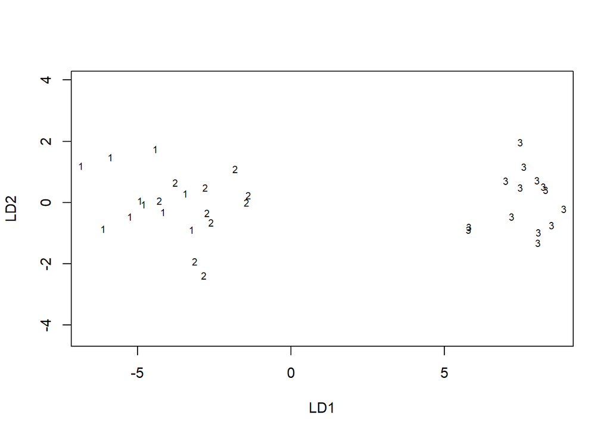

```r
plot(discrimi)
```

Grafico de las puntuaciones discriminantes de los datos

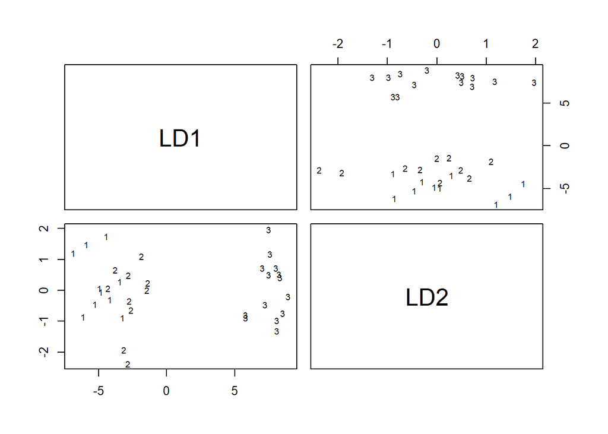

```r
pairs(discrimi)
```

Finalmente, obtenemos el histograma de las variables dependientes frente a la variable de agrupacion.

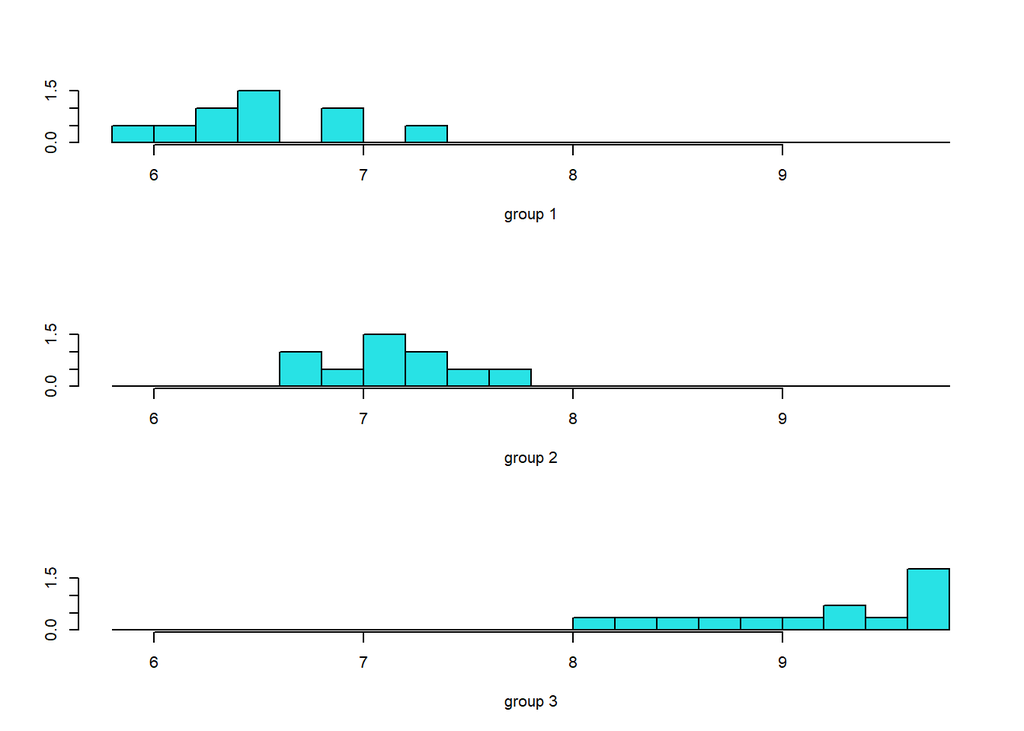

```r
ldahist(datos$X1,datos$ansiedad)
```

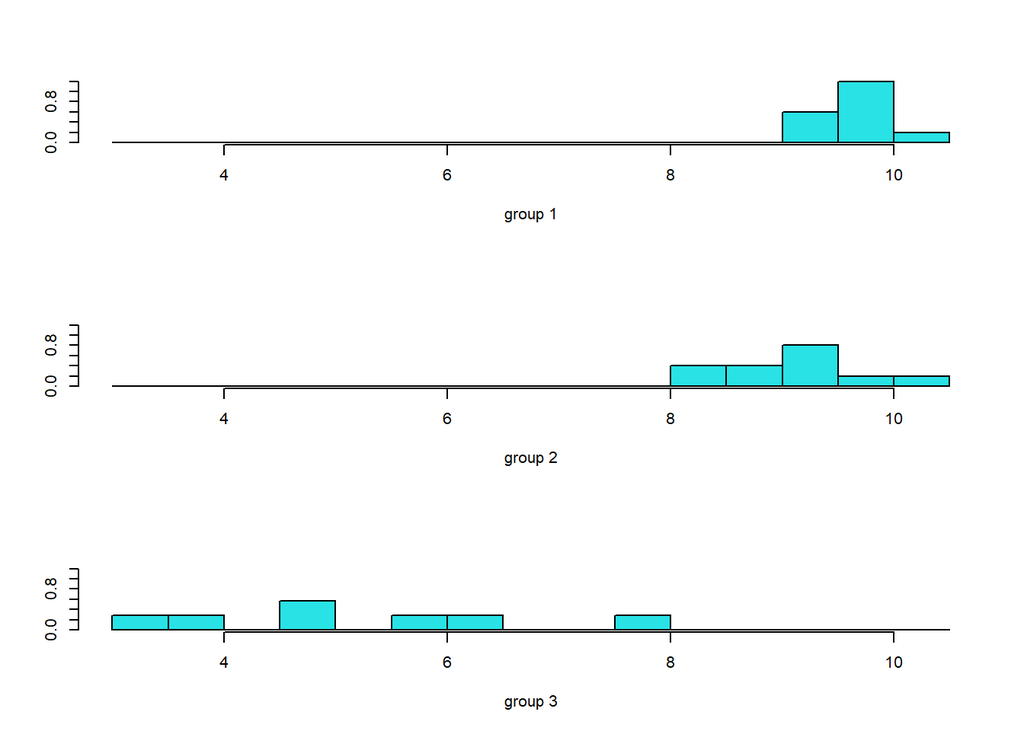

```r
ldahist(datos$X2,datos$ansiedad)
```

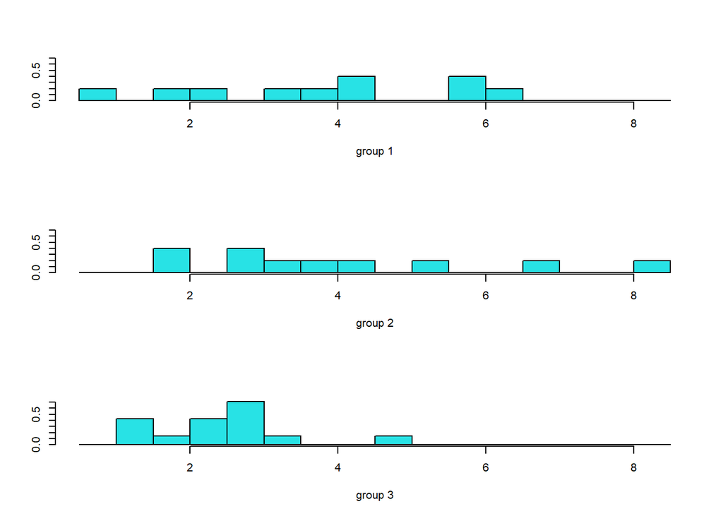

```r
ldahist(datos$X3,datos$ansiedad)
```

Validez del modelo

Al principio del analisis vimos como no se cumplen los supuestos de normalidad y variabilidad constante para el conjunto estudiado. Esto no nos permite declarar como valido el modelo planteado. Una opcion que podemo tomar para poder completar de forma adecuada el analisis seria hacer exploraciones para encontrar una transformacion adecuada de los datos que nos permitan validar los supuestos.